# Bài 2: Histogram ảnh

Import thư viện

```python
import cv2
import numpy as np
import matplotlib.pyplot as plt
```

# 2.1. Viết hàm vẽ Histogram cho trước không sử dụng thư viện

```python
def compute_hist(img):
    hist = np.zeros((256,), np.uint32)
    h, w = img.shape[:2]
    for i in range(h):
        for j in range(w):
            hist[img[i][j]] += 1
    return hist
```

# 2.2. Viết hàm cân bằng Histogram của 1 ảnh không sử dụng thư viện

```python
def equal_hist(img):
    hist = np.zeros((256,), np.uint32)
    [w, h] = img.shape[:2]
    for i in range(w):
        for j in range(h):
            hist[img[i][j]]+=1
    cdf = np.cumsum(hist)
    sk = np.uint32(256 * cdf / np.max(cdf))
    return sk[img]
```

# 2.3. Cho ảnh .png và .tif

# a. Đọc ảnh, chuyển ảnh sang ảnh xám

Đọc ảnh, chuyển sang ảnh xám

```python
img_1 = cv2.imread("D:\Programming\Computer Vision\Projects\Images\lab1.jpg")
img_2 = cv2.imread("D:\Programming\Computer Vision\Projects\Images\Lab2.tif")
img_3 = cv2.imread("D:\Programming\Computer Vision\Projects\Images\Lab3.tif")
img_gray_1 = cv2.cvtColor(img_1, cv2.COLOR_BGR2GRAY)
img_gray_2 = cv2.cvtColor(img_2, cv2.COLOR_BGR2GRAY)
img_gray_3 = cv2.cvtColor(img_3, cv2.COLOR_BGR2GRAY)
```

Hiển thị ảnh xám

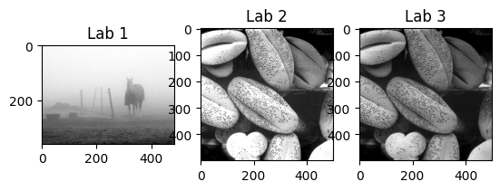

```python
plt.subplot(1,3,1)
plt.imshow(img_gray_1,"gray")
plt.title('Lab 1')
plt.subplot(1,3,2)
plt.imshow(img_gray_2,"gray")
plt.title('Lab 2')
plt.subplot(1,3,3)
plt.imshow(img_gray_3,"gray")
plt.title('Lab 3')
plt.show()
```

Histogram các ảnh

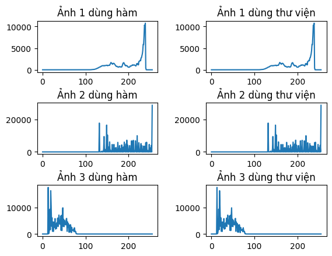

```python
hist_1 = compute_hist(img_gray_1)
hist_1_cv2 = cv2.calcHist([img_gray_1], [0], None, [256], [0, 256])
hist_2 = compute_hist(img_gray_2)
hist_2_cv2 = cv2.calcHist([img_gray_2], [0], None, [256], [0, 256])
hist_3 = compute_hist(img_gray_3)
hist_3_cv2 = cv2.calcHist([img_gray_3], [0], None, [256], [0, 256])

plt.subplot(3,2,1)
plt.plot(hist_1)
plt.title('Ảnh 1 dùng hàm')
plt.subplot(3,2,2)
plt.plot(hist_1_cv2)
plt.title('Ảnh 1 dùng thư viện')
plt.subplot(3,2,3)
plt.plot(hist_2)
plt.title('Ảnh 2 dùng hàm')
plt.subplot(3,2,4)
plt.plot(hist_2_cv2)
plt.title('Ảnh 2 dùng thư viện')
plt.subplot(3,2,5)
plt.plot(hist_3)
plt.title('Ảnh 3 dùng hàm')
plt.subplot(3,2,6)
plt.plot(hist_3_cv2)
plt.title('Ảnh 3 dùng thư viện')
plt.subplots_adjust(wspace=0.4, hspace=0.6)
plt.show()
```

So sánh: Histogram tính bởi hàm tương tự như Histogram tính bởi thư viện

# c. Biến đổi gamma correction, piecewise linear transformation

Viết hàm Gamma correction

```python
def gamma_ajust(image, gamma):
  image = np.power(image, gamma)
  max_val = np.max(image.ravel())
  image = image/max_val * 255
  image = image.astype(np.uint8)
  return image
```

Biến đổi gamma correction

```python
gamma_img_1 = gamma_ajust(img_gray_1, 1.9)
gamma_img_2 = gamma_ajust(img_gray_2, 1.9)
gamma_img_3 = gamma_ajust(img_gray_3, 1.9)
```

Biến đổi Piecewise linear transformation

```python
# Thiết lập các điểm của biến đổi tuyến tính theo mảnh
points_in = np.array([[0, 0], [50, 80], [150, 100], [255, 255]], dtype=np.uint8)
points_out = np.array([[0, 0], [100, 50], [150, 200], [255, 255]], dtype=np.uint8)

# Tạo hàm ánh xạ từ các điểm đã cho
trans_func = np.zeros((256,), dtype=np.uint8)

# Xác định hàm ánh xạ
for i in range(len(points_in) - 1):
    x1, y1 = points_in[i]
    x2, y2 = points_in[i + 1]
    for x in range(x1, x2 + 1):
        y = int(y1 + (x - x1) * (y2 - y1) / (x2 - x1))
        trans_func[x] = np.clip(y, 0, 255)

# Biến đổi ảnh sử dụng hàm ánh xạ
PLT_img_1 = cv2.LUT(img_gray_1, trans_func)
PLT_img_2 = cv2.LUT(img_gray_2, trans_func)
PLT_img_3 = cv2.LUT(img_gray_3, trans_func)
```

Hiển thị ảnh gốc, gamma correction, piecewise linear transformation

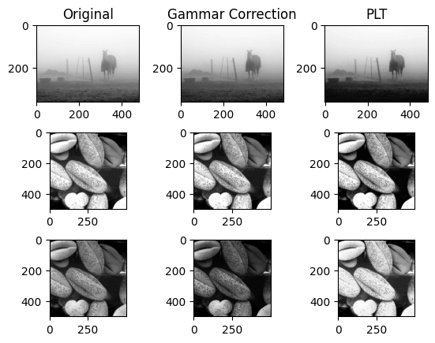

```python
plt.subplot(331), plt.imshow(img_gray_1,"gray")
plt.title('Original')
plt.subplot(332), plt.imshow(gamma_img_1,"gray")
plt.title('Gammar Correction')
plt.subplot(333), plt.imshow(PLT_img_1,"gray")
plt.title('PLT')
plt.subplot(334), plt.imshow(img_gray_2,"gray")
plt.subplot(335), plt.imshow(gamma_img_2,"gray")
plt.subplot(336), plt.imshow(PLT_img_2,"gray")
plt.subplot(337), plt.imshow(img_gray_3,"gray")
plt.subplot(338), plt.imshow(gamma_img_3,"gray")
plt.subplot(339), plt.imshow(PLT_img_3,"gray")
plt.subplots_adjust(wspace=0.4, hspace=0.4)
plt.show()
```

# d. Cân bằng histogram cho ảnh bằng hàm và thư viện, so sánh kết quả. So sánh cân bằng histogram với gamma correction, piecewise linear transformation

Cân bằng histogram bằng hàm và thư viện

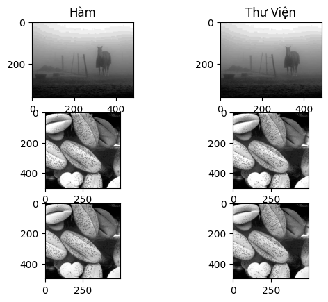

```python
equal_hist_1 = equal_hist(img_gray_1)
equal_hist_2 = equal_hist(img_gray_2)
equal_hist_3 = equal_hist(img_gray_3)
equal_hist_1_cv2 = cv2.equalizeHist(img_gray_1)
equal_hist_2_cv2 = cv2.equalizeHist(img_gray_2)
equal_hist_3_cv2 = cv2.equalizeHist(img_gray_3)

plt.subplot(321), plt.imshow(equal_hist_1,"gray")
plt.title('Hàm')
plt.subplot(322), plt.imshow(equal_hist_1_cv2,"gray")
plt.title('Thư Viện')
plt.subplot(323), plt.imshow(equal_hist_2,"gray")
plt.subplot(324), plt.imshow(equal_hist_2_cv2,"gray")
plt.subplot(325), plt.imshow(equal_hist_3,"gray")
plt.subplot(326), plt.imshow(equal_hist_3_cv2,"gray")

plt.show()
```

So sánh: Cân bằng Histogram tính bởi hàm tương tự như cân bằng Histogram tính bởi thư viện. Cân bằng Histogram cho ảnh rõ nét hơn các phương pháp Gamma Correction, Piecewise Linear Transformation

# 2.4. Cân bằng histogram cục bộ ảnh

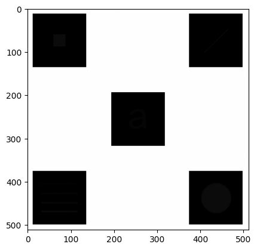

```python
img_4 = cv2.imread("D:\Programming\Computer Vision\Projects\Images\Lab4.tif")
img_gray_4 = cv2.cvtColor(img_4, cv2.COLOR_BGR2GRAY)
plt.imshow(img_gray_4,"gray")
```

Viết hàm cân bằng histogram cục bộ

```python
def local_hist_equal(image, clip_limit=20, grid_size=(8, 8)):
    clahe = cv2.createCLAHE(clipLimit=clip_limit, tileGridSize=grid_size)
    equalized_image = clahe.apply(image)
    return equalized_image
```

Biến đổi histogram cục bộ

```python
#Histogram ban đầu
hist_4_org = compute_hist(img_gray_4)

#Histogram cục bộ
equal_img_4 = local_hist_equal(img_gray_4)
hist_4 = compute_hist(equal_img_4)
```

Hiển thị histogram gốc và cục bộ

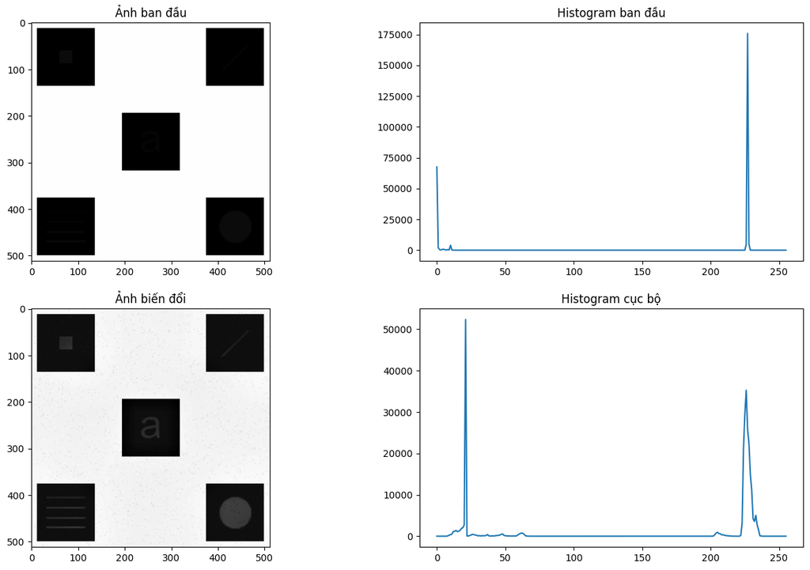

```python
plt.subplots(1, 2, figsize=(16, 10))
plt.subplot(221), plt.imshow(img_gray_4,"gray")
plt.title('Ảnh ban đầu')
plt.subplot(222), plt.plot(hist_4_org)
plt.title('Histogram ban đầu')
plt.subplot(223), plt.imshow(equal_img_4,"gray")
plt.title('Ảnh biến đổi')
plt.subplot(224), plt.plot(hist_4)
plt.title('Histogram cục bộ')
plt.show()
```